# Fun with fonts

The default fonts in R might not be that interesting to you. Here is how you can get a little more flexibility.

# Required packages

These example uses the following packages:

```r
library(tidyverse)
library(extrafont)
library(extrafontdb)
library(ggspatial)
```

# Loading some sample data

Let’s start with this nice map I created that shows bus stop and trails in San Luis Obispo.

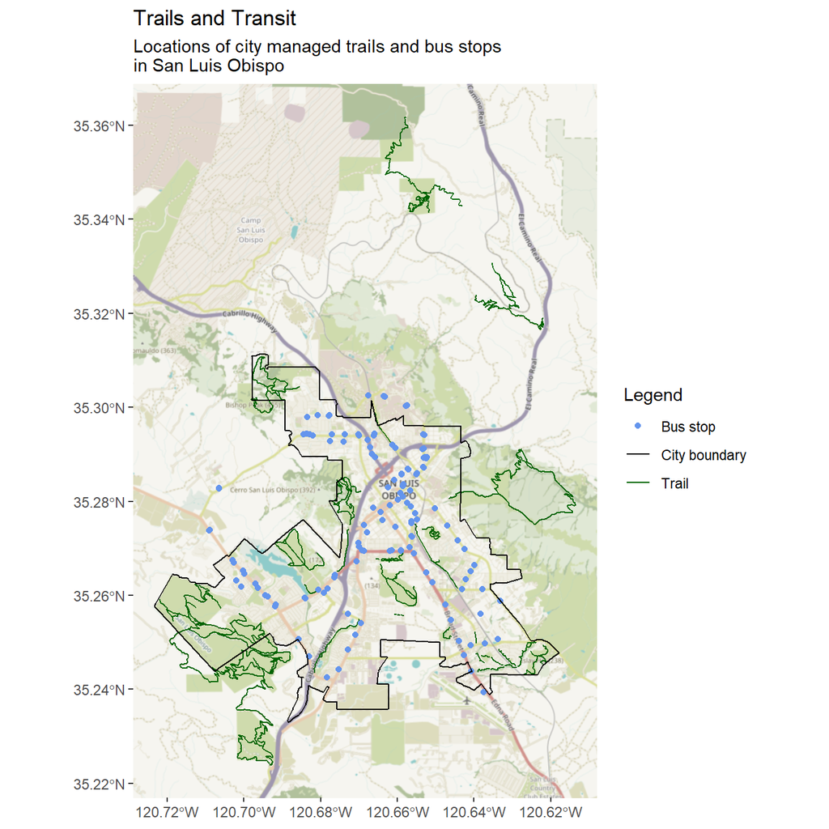

```r
slo_map
```

There are a few different text elements on this map. There are the axis labels, the text in the legend, the plot title, and the map annotation. The default font is Arial, and it’s fine. But maybe you want more options.

To make all the fonts on your computer available to R, type `font_import()` into your console and press Enter. You should only need to ever do this once. It takes some time to import all the fonts, so you’ll get a prompt to type y or n (yes or no) to confirm that you really want to do that. Type `y` and press Enter.

If you are seeing a lot of messages that say “No FontName. Skipping.”, try typing `remotes::install_version("Rttf2pt1", version = "1.3.8")` into your console, then try again (a newer version of one of the packages `extrafonts` depends on seems to be a little broken, so this takes it back to an old one).

Now you can use the `fonts()` function to see a list of all the fonts that are available to you. Here’s what I have on my computer (it’s a PC).

```r
fonts()
```

```
##   [1] "Agency FB"                       "Algerian"
##   [3] "Arial Black"                     "Arial"
##   [5] "Arial Narrow"                    "Arial Rounded MT Bold"
##   [7] "Bahnschrift"                     "Barlow Black"
##   [9] "Barlow"                          "Barlow ExtraBold"
##  [11] "Barlow ExtraLight"               "Barlow Light"
##  [13] "Barlow Medium"                   "Barlow SemiBold"
##  [15] "Barlow Thin"                     "Baskerville Old Face"
##  [17] "Bauhaus 93"                      "Bell MT"
##  [19] "Berlin Sans FB"                  "Berlin Sans FB Demi"
##  [21] "Bernard MT Condensed"            "Blackadder ITC"
##  [23] "Bodoni MT"                       "Bodoni MT Black"
##  [25] "Bodoni MT Condensed"             "Bodoni MT Poster Compressed"
##  [27] "Book Antiqua"                    "Bookman Old Style"
##  [29] "Bookshelf Symbol 7"              "Bradley Hand ITC"
```

[output cut: 118 more lines]

Now I need to load these fonts using the function `loadfonts()`. If you are working on a Mac, you can leave leave the parentheses empty (i.e. delete `device = "win"`)

```r
loadfonts(device = "win")
```

# Setting the font for an entire plot

I can set the font for all the text in the font by setting `text =` in the `theme()` function.

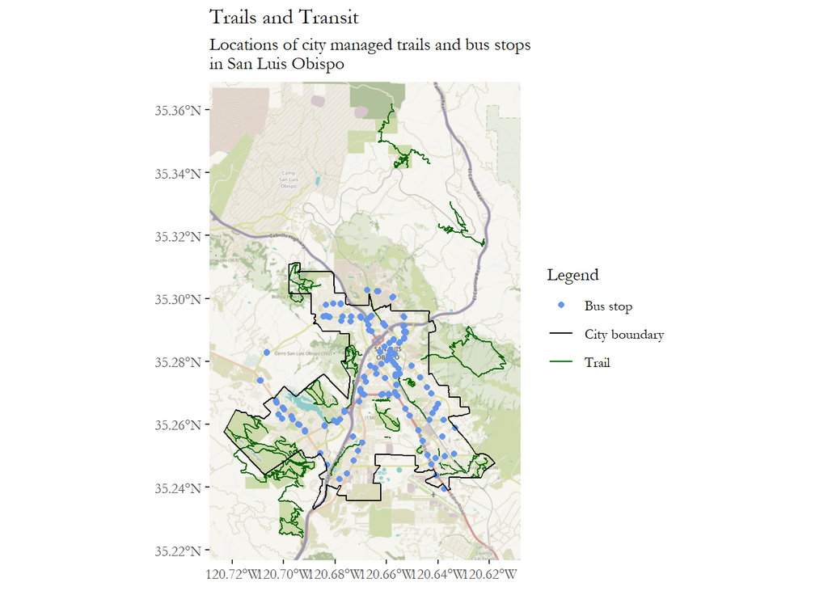

```r
slo_map +
  theme(text = element_text(family = "Garamond"))
```

# Setting the font for individual elements

Maybe you want to use different fonts for different text elements. No problem.

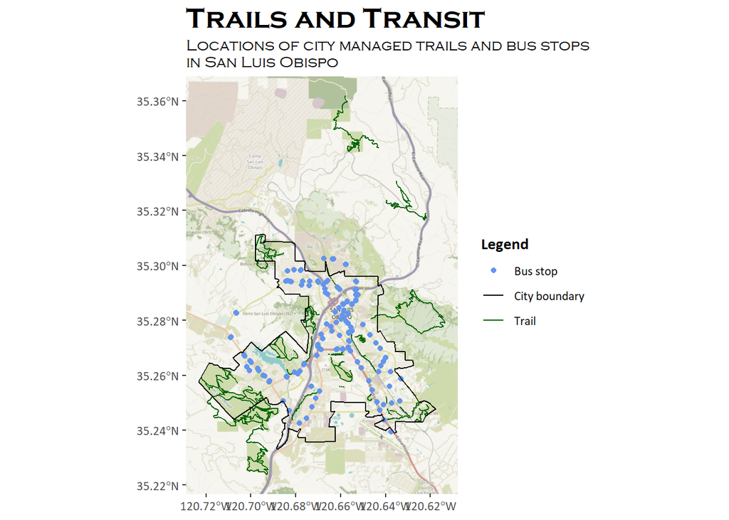

```r
slo_map +
  theme(plot.title = element_text(family = "Copperplate Gothic Bold",
                             size = 20),
        plot.subtitle = element_text(family = "Copperplate Gothic Light"),
        axis.text = element_text(family = "Calibri" ),
        legend.title = element_text(family = "Calibri", face = "bold"),
        legend.text = element_text(family = "Calibri" ))
```

# Setting the font for annotation

There are some map annotation elements like [north arrows](https://c-voulgaris.github.io/VIS-2128-F22/a2-files/skill-north-arrow.html), [scale bars](https://c-voulgaris.github.io/VIS-2128-F22/a2-files/skill-scale-bar.html), and [text annotation](https://c-voulgaris.github.io/VIS-2128-F22/a2-files/skill-annotate.html) where you would set the font separately from the theme.

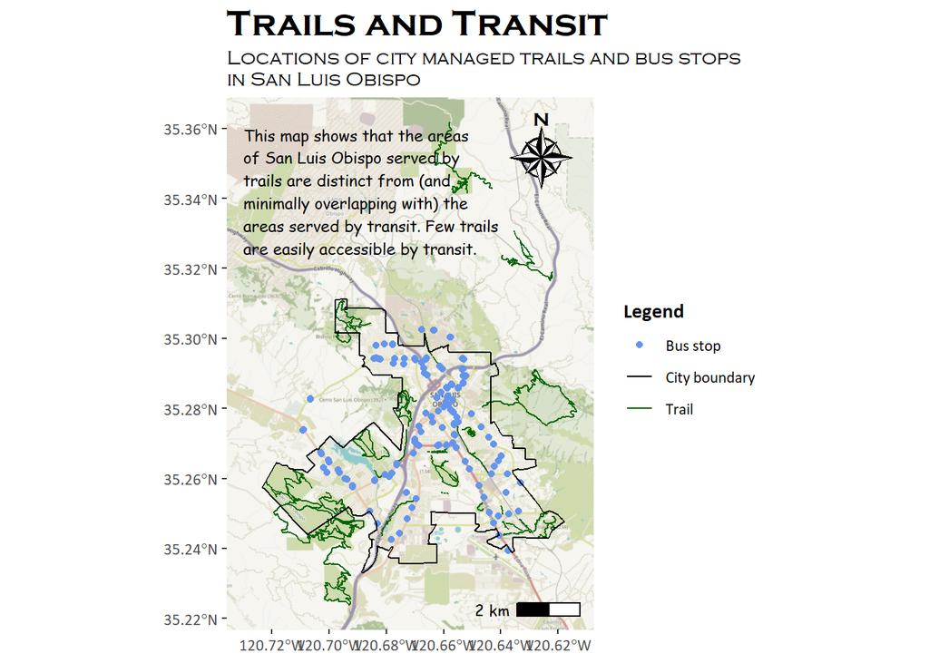

```r
slo_map +
  theme(plot.title = element_text(family = "Copperplate Gothic Bold",
                             size = 20),
        plot.subtitle = element_text(family = "Copperplate Gothic Light"),
        axis.text = element_text(family = "Calibri" ),
        legend.title = element_text(family = "Calibri", face = "bold"),
        legend.text = element_text(family = "Calibri" )) +
  annotate(geom = "text",
           x = -120.73,
           y = 35.36,
           hjust = 0,
           vjust = 1,
           family = "Comic Sans MS",
           size = 3,
           label = "This map shows that the areas\nof San Luis Obispo served by\ntrails are distinct from (and \nminimally overlapping with) the\nareas served by transit. Few trails\nare easily accessible by transit.") +
  annotation_north_arrow(location = "tr",
                         style = north_arrow_nautical(text_family = "Copperplate Gothic Bold")) +
  annotation_scale(location = "br",
                   text_family = "Comic Sans MS")
```